# Задачи по Эконометрике: Мультиколлинеарность

Н.В. Артамонов (МГИМО МИД России)

# 1 sleep equation #1

## 1.1 VIFs

Для набора данных `sleep75` рассмотрим линейную регрессию **sleep на totwrk/100, totwrk<sup>2</sup>/10000, age, smsa, male**.

Какие регрессии нужно рассматривать для вычисления показателей VIF для коэффициентов **totwrk, totwrk^2, male** ? Ответ

- **totwrk/100 на totwrk<sup>2</sup>/10000, age, smsa, male**
- **totwrk<sup>2</sup>/10000 на totwrk/100, age, smsa, male**
- **male на totwrk/100, totwrk<sup>2</sup>/10000, age, smsa**

Результаты подгонки:

```
================================================================
                                Зависимая переменная
                    --------------------------------------------
                    `I(totwrk/100)` `I(totwrk2/10000)`   male
                          (1)              (2)            (3)
----------------------------------------------------------------
`I(totwrk2/10000)`     0.021***                        -0.00003
                       (0.0003)                        (0.0001)

`I(totwrk/100)`                         40.125***      0.021***
                                         (0.609)        (0.005)

age                     -0.008            0.038          0.002
                        (0.011)          (0.470)        (0.002)

smsa                     0.357           -19.824*        0.008
                        (0.259)          (11.176)       (0.036)

male                   1.071***           -2.883
                        (0.265)          (11.610)

south                  0.989***         -37.165***      -0.066
                        (0.327)          (14.148)       (0.046)

Constant               9.003***        -296.595***       0.057
                        (0.498)          (23.551)       (0.085)

----------------------------------------------------------------
Observations              706              706            706
R2                       0.882            0.879          0.147
Adjusted R2              0.881            0.878          0.141
Residual Std. Error      3.265           141.176         0.460
F Statistic           1047.211***      1019.216***     24.165***
================================================================
Note:                                *p<0.1; **p<0.05; ***p<0.01
```

Вычислите VIF для **totwrk/100, totwrk<sup>2</sup>/10000, male**. **Ответ округлите до 2-х десятичных знаков.**

Ответ

```
    I(totwrk/100) I(totwrk^2/10000)              male
             8.47              8.26              1.17
```

## 1.2 Последствия

Для набора данных `sleep75` рассмотрим линейную регрессию **sleep на totwrk/100, totwrk<sup>2</sup>/10000, age, smsa, male**.

Результаты оценивания:

```
===============================================
                       Зависимая переменная
                    ---------------------------
                               sleep
-----------------------------------------------
I(totwrk/100)                 -8.195*
                              (4.789)

I(totwrk2/10000)              -0.214*
                              (0.111)

age                           2.817**
                              (1.387)

smsa                         -78.049**
                             (32.072)

male                         86.639**
                             (34.200)

Constant                    3428.805***
                             (76.655)

-----------------------------------------------
Observations                    706
R2                             0.128
Adjusted R2                    0.122
Residual Std. Error           416.457
F Statistic                  20.566***
===============================================
Note:               *p<0.1; **p<0.05; ***p<0.01
```

Уровень значимости 5%. Какие коэффициенты значимы? Ответ

```
[1] "age"  "smsa" "male"
```

Тестируется значимость влияния занятости, т.е. гипотеза $H_0:\beta_{totwrk/100}=\beta_{totwrk^2/10000}=0$.

Результаты тестирования:

```
==============
F      Pr(> F)
--------------
45.619    0
--------------
```

Вычислите необходимое критическое значение. **Ответ округлите до 2-х десятичных знаков.**

```
[1] 3.01
```

Какие результаты тестирования? Ответ

```
[1] "Гипотеза отвергается"
```

**На первый взгляд противоречие.**

Потестируем модель на мультиколлинеарность. Посмотрим на VIF для регрессоров

```
    I(totwrk/100) I(totwrk^2/10000)               age              smsa
         8.370495          8.199290          1.005968          1.004459
             male
         1.169198
```

и на корреляции

```
                  I(totwrk/100) I(totwrk^2/10000)    age   smsa  male
I(totwrk/100)             1.000             0.937 -0.050 -0.038 0.376
I(totwrk^2/10000)         0.937             1.000 -0.046 -0.051 0.351
age                      -0.050            -0.046  1.000  0.025 0.032
smsa                     -0.038            -0.051  0.025  1.000 0.007
male                      0.376             0.351  0.032  0.007 1.000
```

Визуализация корреляций

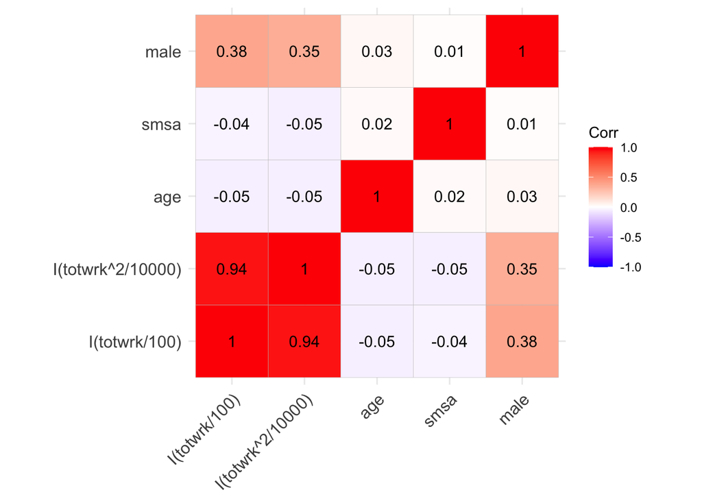

# 2 sleep equation #2

## 2.1 VIFs

Для набора данных `sleep75` рассмотрим линейную регрессию **sleep на totwrk, age, age<sup>2</sup>, smsa, male, south**.

Какие регрессии нужно рассматривать для вычисления показателей VIF для коэффициентов **age, age<sup>2</sup>, male** ? Ответ

- **age на totwrk, age, smsa, male, south**
- **age<sup>2</sup> на totwrk, age, smsa, male, south**
- **male на totwrk, age, age<sup>2</sup> smsa, south**

Результаты подгонки:

```
======================================================
                           Зависимая переменная
                    ----------------------------------
                        age      `I(age2)`     male
                        (1)         (2)         (3)
------------------------------------------------------
totwrk               0.0002***   -0.019***   0.0002***
                     (0.0001)     (0.005)    (0.00002)

`I(age2)`            0.012***                 0.00004
                     (0.0001)                (0.0001)

age                              83.036***    -0.001
                                  (0.392)     (0.012)

smsa                   0.014       -0.555      0.008
                      (0.111)     (9.320)     (0.036)

male                  -0.011       2.636
                      (0.116)     (9.682)

south                 -0.208       17.250     -0.066
                      (0.141)     (11.798)    (0.046)

Constant             19.015***  -1552.146***   0.129
                      (0.173)     (19.639)    (0.241)

------------------------------------------------------
Observations            706         706         706
R2                     0.985       0.985       0.147
Adjusted R2            0.985       0.985       0.141
Residual Std. Error    1.407      117.727      0.460
F Statistic         9025.467*** 9043.509***  24.168***
======================================================
Note:                      *p<0.1; **p<0.05; ***p<0.01
```

Вычислите VIF для **age, age<sup>2</sup>, male**. **Ответ округлите до 2-х десятичных знаков.**

Ответ

```
     age I(age^2)     male
   66.67    66.67     1.17
```

## 2.2 Последствия

Для набора данных `sleep75` рассмотрим линейную регрессию **sleep на totwrk, age, age<sup>2</sup>, smsa, male, union**.

Результаты оценивания:

```
===============================================
                       Зависимая переменная
                    ---------------------------
                               sleep
-----------------------------------------------
totwrk                       -0.165***
                              (0.018)

age                           -7.734
                             (11.213)

I(age2)                        0.127
                              (0.134)

smsa                         -74.527**
                             (32.156)

male                         86.321**
                             (34.329)

union                          8.574
                             (38.195)

Constant                    3688.551***
                             (218.389)

-----------------------------------------------
Observations                    706
R2                             0.125
Adjusted R2                    0.117
Residual Std. Error           417.584
F Statistic                  16.583***
===============================================
Note:               *p<0.1; **p<0.05; ***p<0.01
```

Уровень значимости 10%. Какие коэффициенты значимы? Ответ

```
[1] "totwrk" "smsa"   "male"
```

Тестируется значимость влияния занятости, т.е. гипотеза $H_0:\beta_{age}=\beta_{age^2}=0$.

Результаты тестирования:

```
=============
F     Pr(> F)
-------------
2.497  0.083
-------------
```

Вычислите необходимое критическое значение. **Ответ округлите до 2-х десятичных знаков.**

```
[1] 2.31
```

Какие результаты тестирования? Ответ

```
[1] "Гипотеза отвергается"
```

**На первый взгляд противоречие.**

Потестируем модель на мультиколлинеарность. Посмотрим на VIF для регрессоров

```
   totwrk       age  I(age^2)      smsa      male     union
 1.195469 65.397082 65.561373  1.004278  1.171666  1.007332
```

и на корреляции

```
         totwrk    age I(age^2)   smsa  male  union
totwrk    1.000 -0.050   -0.067 -0.038 0.376  0.002
age      -0.050  1.000    0.992  0.025 0.032 -0.037
I(age^2) -0.067  0.992    1.000  0.024 0.026 -0.042
smsa     -0.038  0.025    0.024  1.000 0.007 -0.039
male      0.376  0.032    0.026  0.007 1.000  0.040
union     0.002 -0.037   -0.042 -0.039 0.040  1.000
```

Визуализация корреляций

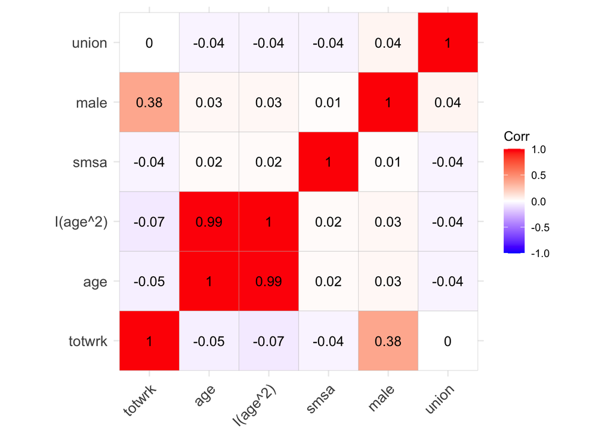

# 3 sleep equation #3

## 3.1 VIFs

Для набора данных `sleep75` рассмотрим линейную регрессию **sleep на totwrk, south, totwrk$\star$south, age, male, smsa**.

Какие регрессии нужно рассматривать для вычисления показателей VIF для коэффициентов **totwrk, south, totwrk$\star$south** ? Ответ

- **totwrk на south, totwrk$\star$south, age, male, smsa**
- **south на totwrk, totwrk$\star$south, age, male, smsa**
- **totwrk$\star$south на totwrk, south, age, male, smsa**

Результаты подгонки:

```
================================================================
                                Зависимая переменная
                    --------------------------------------------
                       totwrk       south    `I(totwrk * south)`
                        (1)          (2)             (3)
----------------------------------------------------------------
south               -1780.732***                 2208.748***
                     (225.404)                    (31.491)

totwrk                           -0.00005***      0.124***
                                  (0.00001)        (0.014)

`I(totwrk * south)`   0.862***    0.0004***
                      (0.094)     (0.00001)

age                    -3.438      0.0004          -1.210
                      (2.759)     (0.0004)         (1.046)

male                 645.996***    -0.007           3.804
                      (63.604)     (0.011)        (25.841)

smsa                  -46.641     -0.024**          2.676
                      (65.561)     (0.010)        (24.876)

Constant            1883.936***   0.116***       -216.759***
                     (120.399)     (0.022)        (52.419)

----------------------------------------------------------------
Observations            706          706             706
R2                     0.241        0.883           0.886
Adjusted R2            0.235        0.882           0.885
Residual Std. Error   828.439       0.133          314.223
F Statistic          44.429***   1057.246***     1082.775***
================================================================
Note:                                *p<0.1; **p<0.05; ***p<0.01
```

Вычислите VIF для **totwrk, south, totwrk$\star$south**. **Ответ округлите до 2-х десятичных знаков.**

Ответ

```
           totwrk             south I(totwrk * south)
             1.32              8.55              8.77
```

## 3.2 Последствия

Для набора данных `sleep75` рассмотрим линейную регрессию **sleep на totwrk, south, totwrk$\star$south, age, male, smsa, marr**.

Результаты оценивания:

```
===============================================
                       Зависимая переменная
                    ---------------------------
                               sleep
-----------------------------------------------
totwrk                       -0.177***
                              (0.019)

south                         -39.982
                             (118.087)

I(totwrk * south)              0.064
                              (0.050)

age                           2.901**
                              (1.386)

male                         86.269**
                             (34.833)

smsa                         -54.647*
                             (33.074)

marr                          29.985
                             (41.857)

Constant                    3458.811***
                             (78.683)

-----------------------------------------------
Observations                    706
R2                             0.133
Adjusted R2                    0.124
Residual Std. Error           415.835
F Statistic                  15.319***
===============================================
Note:               *p<0.1; **p<0.05; ***p<0.01
```

Уровень значимости 5%. Какие коэффициенты значимы? Ответ

```
[1] "totwrk" "age"    "male"
```

Тестируется значимость влияния географической бинарной переменной, т.е. гипотеза $H_0:\beta_{south}=\beta_{totwrk*south}=0$.

Результаты тестирования:

```
=============
F     Pr(> F)
-------------
3.737  0.024
-------------
```

Вычислите необходимое критическое значение. **Ответ округлите до 2-х десятичных знаков.**

```
[1] 3.01
```

Какие результаты тестирования? Ответ

```
[1] "Гипотеза отвергается"
```

**На первый взгляд противоречие.**

Потестируем модель на мультиколлинеарность. Посмотрим на VIF для регрессоров

```
           totwrk             south I(totwrk * south)               age
         1.328161          8.553057          8.734279          1.007988
             male              smsa              marr
         1.216541          1.071376          1.048792
```

и на корреляции

```
                  totwrk  south I(totwrk * south)    age   male   smsa   marr
totwrk             1.000  0.051             0.175 -0.050  0.376 -0.038 -0.025
south              0.051  1.000             0.932 -0.018 -0.034 -0.238 -0.036
I(totwrk * south)  0.175  0.932             1.000 -0.038  0.018 -0.224 -0.038
age               -0.050 -0.018            -0.038  1.000  0.032  0.025  0.018
male               0.376 -0.034             0.018  0.032  1.000  0.007  0.167
smsa              -0.038 -0.238            -0.224  0.025  0.007  1.000 -0.081
marr              -0.025 -0.036            -0.038  0.018  0.167 -0.081  1.000
```

Визуализация корреляций

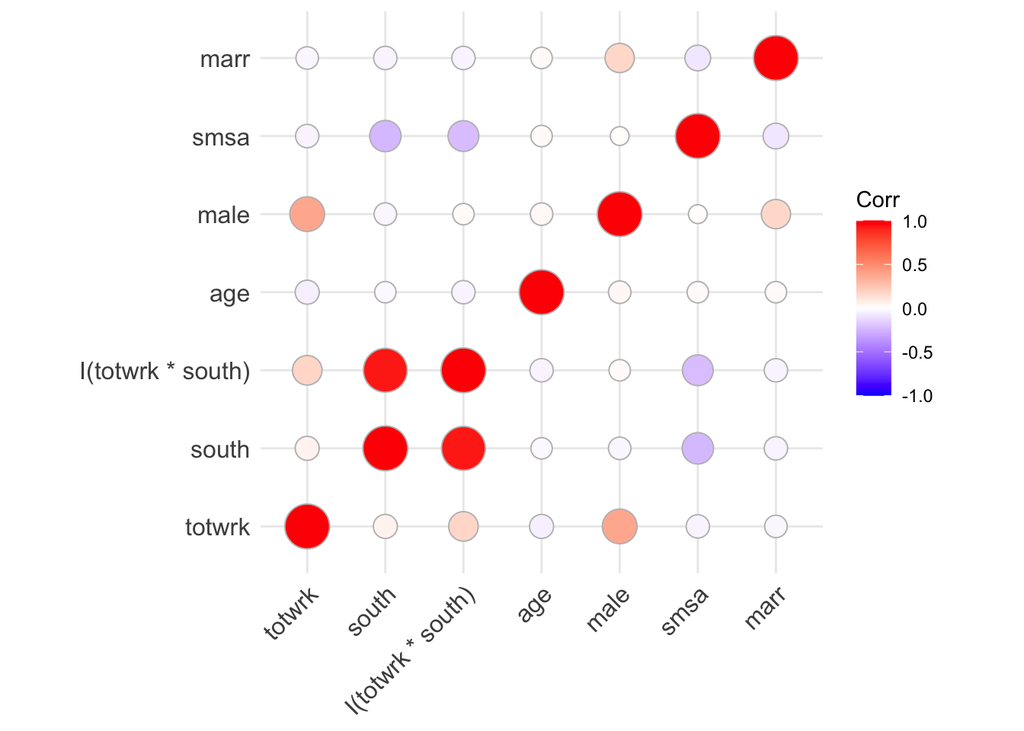

# 4 wage equation #1

## 4.1 VIFs

Для набора данных `wage2` рассмотрим линейную регрессию **log(wage) на age, age^2, IQ, married, south, urban**.

Какие регрессии нужно рассматривать для вычисления показателей VIF для коэффициентов **age, age^2, urban** ? Ответ

- **age на age^2, IQ, married, south, urban**
- **age^2 на age, IQ, married, south, urban**
- **urban на age, age^2, IQ, married, south**

Результаты подгонки:

```
=========================================================
                            Зависимая переменная
                    -------------------------------------
                         age        `I(age2)`     urban
                         (1)           (2)         (3)
---------------------------------------------------------
`I(age2)`             0.015***                   -0.003
                      (0.00002)                  (0.002)

age                                 66.523***     0.188
                                     (0.087)     (0.118)

IQ                     -0.0001        0.008      0.0005
                      (0.0003)       (0.018)     (0.001)

married                -0.003         0.301      -0.053
                       (0.013)       (0.879)     (0.048)

south                   0.010        -0.698     -0.102***
                       (0.009)       (0.586)     (0.032)

urban                   0.014        -0.962
                       (0.009)       (0.603)

Constant              16.514***   -1096.784***   -2.337
                       (0.039)       (3.612)     (1.963)

---------------------------------------------------------
Observations             935           935         935
R2                      0.998         0.998       0.016
Adjusted R2             0.998         0.998       0.011
Residual Std. Error     0.124         8.247       0.448
F Statistic         117401.200*** 117419.000*** 3.112***
=========================================================
Note:                         *p<0.1; **p<0.05; ***p<0.01
```

Вычислите VIF для **age, age^2, urban**. **Ответ округлите до 2-х десятичных знаков.**

Ответ

```
     age I(age^2)    urban
  500.00   500.00     1.02
```

## 4.2 Последствия

Для набора данных `wgae2` рассмотрим линейную регрессию **log(wage) на age, age^2, IQ, married, south, urban**.

Результаты оценивания:

```
===============================================
                       Зависимая переменная
                    ---------------------------
                             log(wage)
-----------------------------------------------
age                            0.145
                              (0.100)

I(age2)                       -0.002
                              (0.002)

IQ                           0.008***
                              (0.001)

married                      0.202***
                              (0.040)

south                        -0.100***
                              (0.027)

urban                        0.173***
                              (0.028)

Constant                      2.938*
                              (1.656)

-----------------------------------------------
Observations                    935
R2                             0.201
Adjusted R2                    0.196
Residual Std. Error            0.378
F Statistic                  38.898***
===============================================
Note:               *p<0.1; **p<0.05; ***p<0.01
```

Уровень значимости 5%. Какие коэффициенты значимы? Ответ

```
[1] "IQ"      "married" "south"   "urban"
```

Тестируется значимость влияния занятости, т.е. гипотеза $H_0:\beta_{age}=\beta_{age^2}=0$.

Результаты тестирования:

```
==============
F      Pr(> F)
--------------
14.833 0.00000
--------------
```

Вычислите необходимое критическое значение. **Ответ округлите до 2-х десятичных знаков.**

```
[1] 3.01
```

Какие результаты тестирования? Ответ

```
[1] "Гипотеза отвергается"
```

**На первый взгляд противоречие.**

Потестируем модель на мультиколлинеарность. Посмотрим на VIF для регрессоров

```
       age   I(age^2)         IQ    married      south      urban
632.868517 632.964483   1.049260   1.013807   1.061287   1.016749
```

и на корреляции

```
            age I(age^2)     IQ married  south  urban
age       1.000    0.999 -0.044   0.107 -0.029 -0.007
I(age^2)  0.999    1.000 -0.043   0.107 -0.031 -0.009
IQ       -0.044   -0.043  1.000  -0.015 -0.210  0.039
married   0.107    0.107 -0.015   1.000  0.023 -0.040
south    -0.029   -0.031 -0.210   0.023  1.000 -0.110
urban    -0.007   -0.009  0.039  -0.040 -0.110  1.000
```

Визуализация корреляций

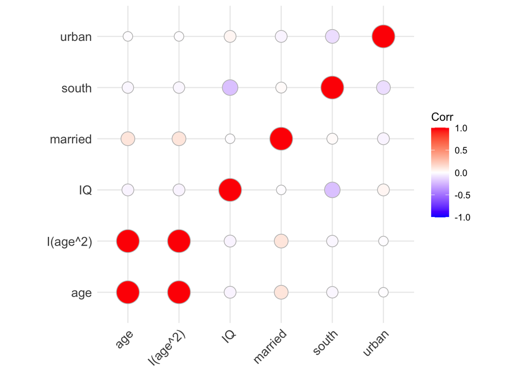

# 5 wage equation #2 (структурные сдвиги)

## 5.1 VIFs

Для набора данных `wage2` рассмотрим линейную регрессию **log(wage) на age, urban, age$\star$urban, IQ, IQ$\star$urban**.

Какие регрессии нужно рассматривать для вычисления показателей VIF для коэффициентов **age, urban, age$\star$urban** ? Ответ

- **age на urban, age$\star$urban, IQ, IQ$\star$urban**
- **urban на age, age$\star$urban, IQ, IQ$\star$urban**
- **age$\star$urban на age, urban, IQ, IQ$\star$urban**

Результаты подгонки:

```
============================================================
                              Зависимая переменная
                    ----------------------------------------
                       age        urban     `I(age * urban)`
                       (1)         (2)            (3)
------------------------------------------------------------
urban               -33.242***                 33.565***
                     (1.111)                    (0.692)

age                             -0.015***       0.698***
                                 (0.0005)       (0.015)

`I(age * urban)`     1.000***    0.021***
                     (0.022)     (0.0004)

IQ                    -0.001    -0.002***        0.001
                     (0.007)     (0.0001)       (0.006)

`I(IQ * urban)`       0.001      0.003***        -0.005
                     (0.008)     (0.0001)       (0.007)

Constant            33.242***    0.688***      -23.206***
                     (0.692)     (0.015)        (0.764)

------------------------------------------------------------
Observations           935         935            935
R2                    0.699       0.994          0.991
Adjusted R2           0.698       0.994          0.991
Residual Std. Error   1.709       0.036          1.428
F Statistic         539.592*** 36288.320***   25938.390***
============================================================
Note:                            *p<0.1; **p<0.05; ***p<0.01
```

Вычислите VIF для **age, urban, age$\star$urban**. **Ответ округлите до 2-х десятичных знаков.**

Ответ

```
           age          urban I(age * urban)
          3.32         166.67         111.11
```

## 5.2 Последствия

Для набора данных `wgae2` рассмотрим линейную регрессию **log(wage) на age, IQ, south, urban, age$\star$urban, IQ$\star$urban, south$\star$urban**.

Результаты оценивания:

```
===============================================
                       Зависимая переменная
                    ---------------------------
                             log(wage)
-----------------------------------------------
age                          0.024***
                              (0.007)

IQ                           0.008***
                              (0.002)

south                         -0.014
                              (0.052)

urban                          0.237
                              (0.368)

I(age * urban)                -0.001
                              (0.009)

I(IQ * urban)                -0.00001
                              (0.002)

I(south * urban)              -0.117*
                              (0.061)

Constant                     4.999***
                              (0.312)

-----------------------------------------------
Observations                    935
R2                             0.182
Adjusted R2                    0.176
Residual Std. Error            0.382
F Statistic                  29.417***
===============================================
Note:               *p<0.1; **p<0.05; ***p<0.01
```

Уровень значимости 1%. Какие коэффициенты значимы? Ответ

```
[1] "age" "IQ"
```

Тестируется значимость влияния места жительства, т.е. гипотеза $H_0:\beta_{urban}=\beta_{age*urban}=\beta_{IQ*urban}=\beta_{south*urban}=0$.

Результаты тестирования:

```
==============
F      Pr(> F)
--------------
10.250 0.00000
--------------
```

Вычислите необходимое критическое значение. **Ответ округлите до 2-х десятичных знаков.**

```
[1] 3.34
```

Какие результаты тестирования? Ответ

```
[1] "Гипотеза отвергается"
```

**На первый взгляд противоречие.**

Потестируем модель на мультиколлинеарность. Посмотрим на VIF для регрессоров

```
             age               IQ            south            urban
        3.394929         3.879824         3.832146       175.876722
  I(age * urban)    I(IQ * urban) I(south * urban)
      114.318464        53.135490         4.087171
```

и на корреляции

```
                    age     IQ  south  urban I(age * urban) I(IQ * urban)
age               1.000 -0.044 -0.029 -0.007          0.137        -0.020
IQ               -0.044  1.000 -0.210  0.039          0.030         0.260
south            -0.029 -0.210  1.000 -0.110         -0.106        -0.136
urban            -0.007  0.039 -0.110  1.000          0.985         0.964
I(age * urban)    0.137  0.030 -0.106  0.985          1.000         0.947
I(IQ * urban)    -0.020  0.260 -0.136  0.964          0.947         1.000
I(south * urban)  0.010 -0.097  0.741  0.334          0.332         0.288
                 I(south * urban)
age                         0.010
IQ                         -0.097
south                       0.741
urban                       0.334
I(age * urban)              0.332
I(IQ * urban)               0.288
I(south * urban)            1.000
```

Визуализация корреляций

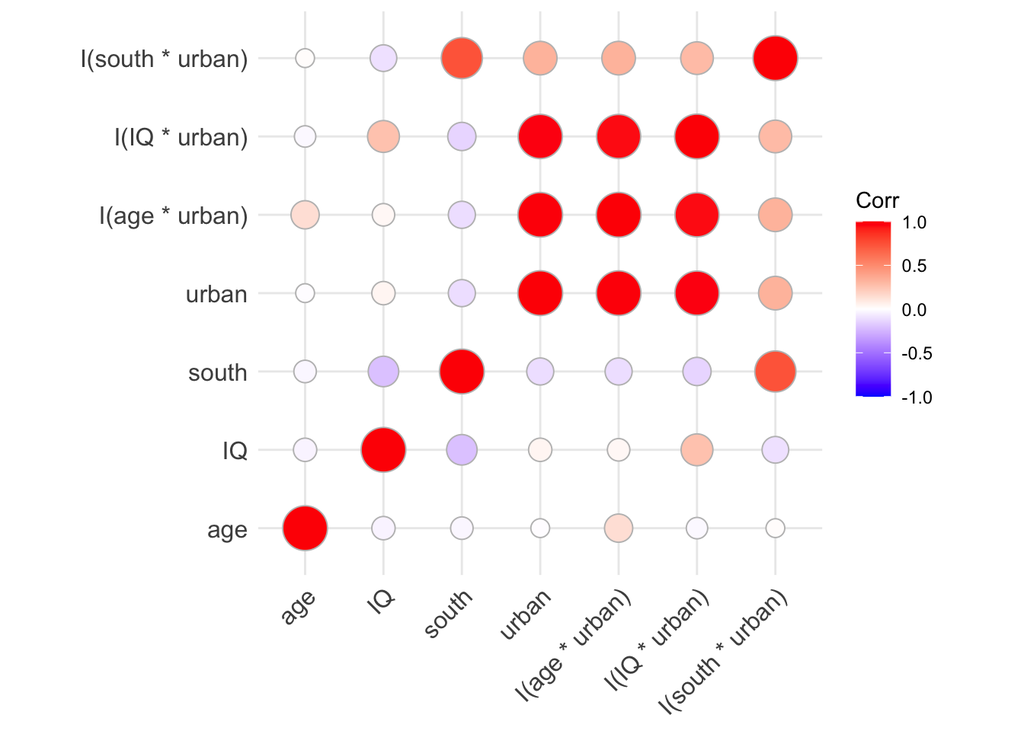